# Hands On 3 Data

## 1 Summarization

1. Obtain the number of cars by bodyStyle.

```r
library(dplyr)
datos <- load("C:/Proyectos ML/Mineria/Hands On_3 Data Exploration/data/carIns_final.Rdata")
data <- as.data.frame(carIns_final)
filtered_num <- data %>% group_by(bodyStyle)%>%unique() %>% count()
```

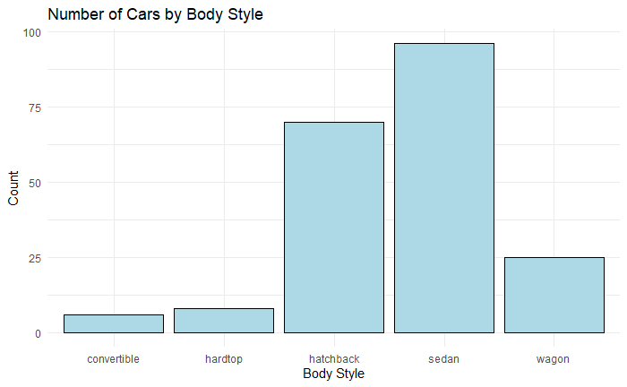

```r
library(ggplot2)
# Create a bar plot of car counts by bodyStyle
ggplot(data, aes(x = bodyStyle)) +
  geom_bar(fill = "lightblue", color = "black") +
  labs(x = "Body Style", y = "Count") +
  ggtitle("Number of Cars by Body Style") +
  theme_minimal()
```

2. Obtain the number of cars by bodyStyle and fuelType

```r
 #carIns_final %>% group_by(bodyStyle,cityMpg)%>% count()
data %>% group_by(bodyStyle,fuelType)%>% count()
```

| bodyStyle | fuelType | n |
| --- | --- | --- |
| convertible | gas | 6 |
| hardtop | diesel | 1 |
| hardtop | gas | 7 |
| hatchback | diesel | 1 |
| hatchback | gas | 69 |
| sedan | diesel | 15 |
| sedan | gas | 81 |
| wagon | diesel | 3 |
| wagon | gas | 22 |

3. Obtain the mean and the standard deviation of the attribute cityMpg by bodyStyle in ascending order.

```r
carIns_final %>% group_by(bodyStyle)%>%summarise(cityMpg.mean = mean(cityMpg), cityMpg.sd = sd(cityMpg) )%>% arrange(cityMpg.mean)
```

| bodyStyle | cityMpg.mean | cityMpg.sd |
| --- | --- | --- |
| convertible | 20.50000 | 3.391165 |
| hardtop | 21.62500 | 5.423165 |
| wagon | 24.04000 | 4.217819 |
| sedan | 25.32292 | 6.599035 |
| hatchback | 26.31429 | 7.169870 |

```r
library(ggplot2)
  carIns_final %>% group_by(bodyStyle)%>% summarise(cityMpg.mean = mean(cityMpg),
  cityMpg.sd = sd(cityMpg),carretera = IQR(highwayMpg))
```

| bodyStyle | cityMpg.mean | cityMpg.sd | carretera |
| --- | --- | --- | --- |
| convertible | 20.50000 | 3.391165 | 3.00 |
| hardtop | 21.62500 | 5.423165 | 5.00 |
| hatchback | 26.31429 | 7.169870 | 11.75 |
| sedan | 25.32292 | 6.599035 | 11.25 |
| wagon | 24.04000 | 4.217819 | 7.00 |

## Visualization

5. Show the relationship between the attributes cityMpg and highwayMpg

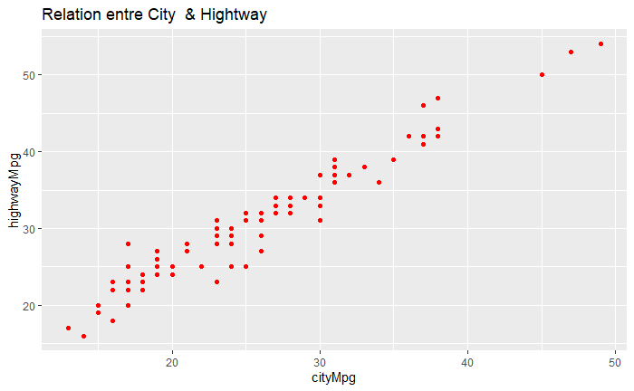

```r
ggplot(carIns_final,aes(x = cityMpg, y = highwayMpg))+geom_point( color = "red")+ggtitle("Relation entre City  & Hightway")
```

6. Show the distribution of cars by bodyStyle.

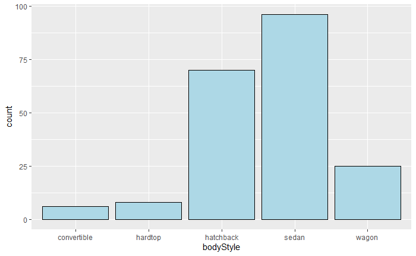

```r
ggplot(carIns_final,aes(x = bodyStyle))+ geom_bar(fill = "lightblue", color = "black")
```

```r
NA
```

7. Show the distribution of cars by price. Suggestion: create bins of width equal to 5000.

[figure not shown]

```r
# Create price bins with a width of 5000
price_bins <- seq(0, max(data$price), by = 5000)
# Cut the prices into bins
price_categories <- cut(data$price, breaks = price_bins, include.lowest = TRUE)
ggplot(carIns_final,aes(x=price_categories))+geom_bar(fill = "lightblue", color = "black")+labs(x = "Price Category", y = "Count") +
  ggtitle("Distribution of Cars by Price")
```

8. Add the information of the density estimation to the previous graph

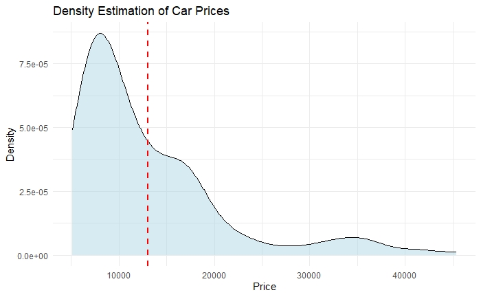

```r
library(ggplot2)
# Create price bins with a width of 5000
price_bins <- seq(0, max(carIns_final$price), by = 5000)
# Cut the prices into bins
data$price_category <- cut(data$price, breaks = price_bins, include.lowest = TRUE)
# Create a density plot of car prices
ggplot(data, aes(x = price)) +
  geom_density(fill = "lightblue", alpha = 0.5) +
  geom_vline(aes(xintercept = mean(price)), color = "red", linetype = "dashed", size = 1) +
  labs(x = "Price", y = "Density") +
  ggtitle("Density Estimation of Car Prices") +
  theme_minimal()
```

1. Check (visually) if it is plausible to consider that price follows a normal distribution.

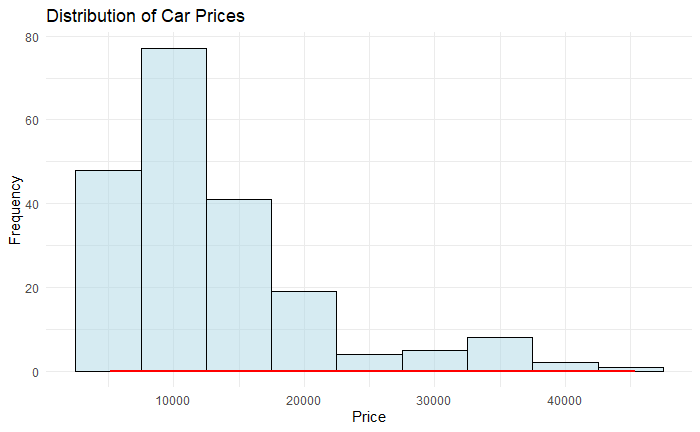

```r
library(ggplot2)
library(dplyr)
library(ggfittext)
# Create a histogram with density curve
ggplot(data, aes(x = price)) +
  geom_histogram(binwidth = 5000, fill = "lightblue", color = "black", alpha = 0.5) +
  stat_function(fun = dnorm, args = list(mean = mean(data$price), sd = sd(data$price)), color = "red", size = 1) +
  labs(x = "Price", y = "Frequency") +
  ggtitle("Distribution of Car Prices") +
  theme_minimal()
```

10. Show the distribution of price by make attribute. Suggestion: use boxplots and the function coord_flip().

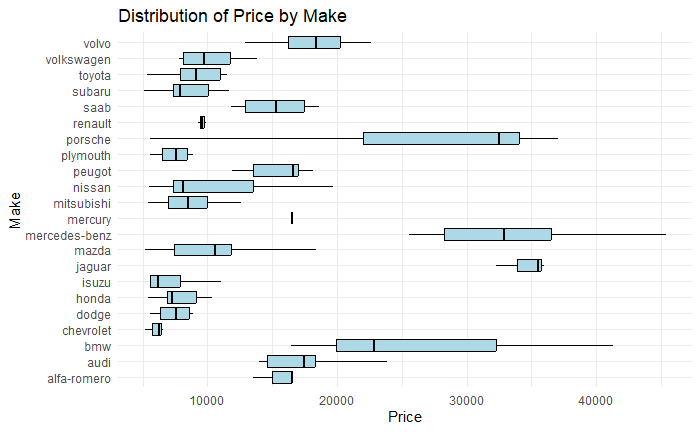

```r
library(ggplot2)
# Create a boxplot of price by make
ggplot(data, aes(x = make, y = price)) +
  geom_boxplot(fill = "lightblue", color = "black", outlier.shape = NA) +
  coord_flip() +
  labs(x = "Make", y = "Price") +
  ggtitle("Distribution of Price by Make") +
  theme_minimal()
```

11. Show the distribution of price by nDoors attribute. Suggestion: use histograms.

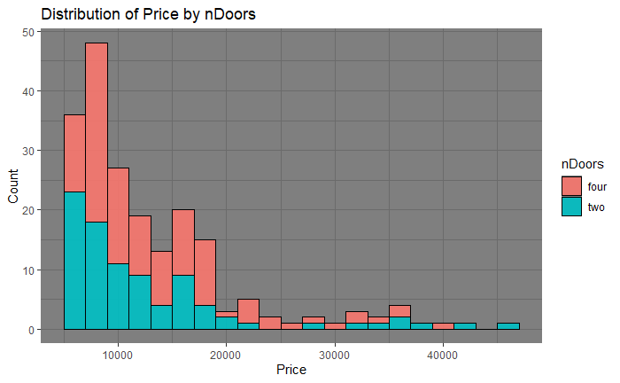

```r
library(ggplot2)
# Create a histogram of price by nDoors
ggplot(data, aes(x = price, fill = nDoors)) +
  geom_histogram(binwidth = 2000, color = "black", alpha = 0.9) +
  labs(x = "Price", y = "Count") +
  ggtitle("Distribution of Price by nDoors") + theme_dark()
```

```r
NA
```

12. Show the distribution of price by bodyStyle and nDoors attributes. Suggestion: use histograms

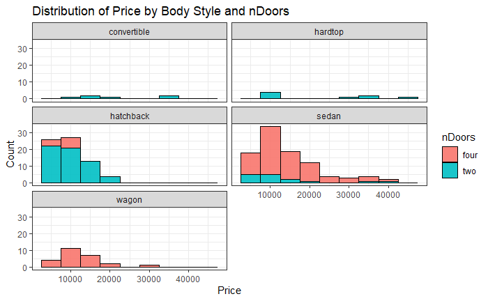

```r
library(ggplot2)
# Create a histogram of price by bodyStyle and nDoors
ggplot(data, aes(x = price, fill = nDoors)) +
  geom_histogram(binwidth = 5000, color = "black", alpha = 0.9) +
  facet_wrap(~ bodyStyle, ncol = 2) +
  labs(x = "Price", y = "Count") +
  ggtitle("Distribution of Price by Body Style and nDoors") +
  theme_bw()
```

13. Add the parameter scales=“free_y” to the facet function in the previous graph.

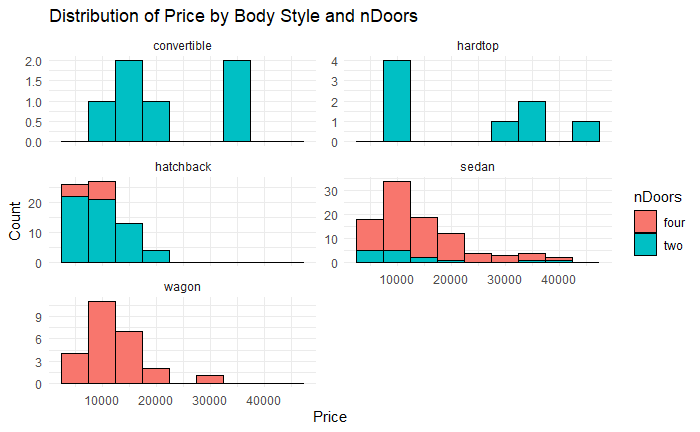

```r
library(ggplot2)
# Create a histogram of price by bodyStyle and nDoors
ggplot(data, aes(x = price, fill = nDoors)) +
  geom_histogram(binwidth = 5000, color = "black", alpha = 1) +
  facet_wrap(~ bodyStyle, scales = "free_y", ncol = 2) +
  labs(x = "Price", y = "Count") +
  ggtitle("Distribution of Price by Body Style and nDoors") +
  theme_minimal()
```